# Inferential Statistics

COMM621

2021-04-19

## P value and statistical significance

**What is a p-value?** A great myth in social science is **p-value**. It is not an intuitive concept to wrap your head around. We use p-value to indicate statistical significance. The magic number here is .05: a p-value below .05 indicates a statistically significant relationship between variables. It indicates there is a 95% chance that the relationship found in the study sample is NOT due to random chances, and thus the finding from the sample accurately reflects the patterns in the population. Note that a p-value says nothing about the “strength of association,” or the meaningfulness of difference.

## T-test

**When to use t-test?** T-test is a simple inferential statistical test used for comparing means across groups. It can reveal whether mean differences across different groups are statistically significant. You typically use t-test when you only have one categorical independent variable (e.g., sex) and one dependent variable.

Below we compare whether there is significant gender difference on the psychological construct called self-esteem.

Let’s inspect the data first. The SEX variable indicates whether a user is a male or female (1=male, 2=female). The column *SELF_ESTEEM* points to a measured self-esteem score reported in 1978 (higher value indicates a higher level of self-esteem).

```r
# in this code block, we download the dataset from a web link and show the data table.
library(readr)
library(DT)

data <- read.csv("https://curiositybits.cc/files/wage_self_esteem.csv")

#show the first 50 observations
datatable(data[1:50,], options = list(pageLength = 5))
```

|  | ID | INCOME | RACE | SEX | SELF_ESTEEM |
| --- | --- | --- | --- | --- | --- |
| 1 | 2 | 4000 | 3 | 2 | 16 |
| 2 | 5 | 2200 | 3 | 1 | 23 |
| 3 | 6 | 1400 | 3 | 1 | 27 |
| 4 | 8 | 200 | 3 | 2 | 23 |
| 5 | 10 | 0 | 3 | 2 | 19 |
| 6 | 12 | 2021 | 3 | 2 | 30 |
| 7 | 13 | 2000 | 3 | 1 | 25 |
| 8 | 16 | 8200 | 3 | 2 | 25 |
| 9 | 17 | 10000 | 3 | 1 | 24 |
| 10 | 18 | 4500 | 3 | 1 | 28 |

[output cut: 40 more lines]

```r
# present descriptive statistics
data$SEX <- as.factor(data$SEX) #treat the column SEX as a factor (i.e., categorical/nominal variable)

#show means across group
aggregate(data$SELF_ESTEEM,by=list(Sex=data$SEX),mean)
```

```
##   Sex        x
## 1   1 23.14541
## 2   2 22.76370
```

We can visualize the group difference through a histogram plot.

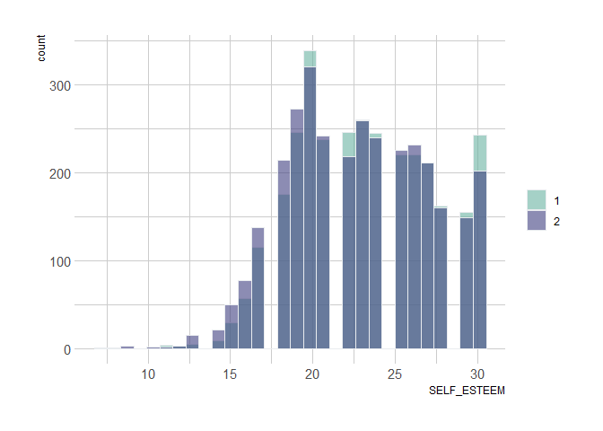

```r
library(ggplot2)
library(hrbrthemes)
#density plot for DV by sex

p <- data %>%
  ggplot( aes(x=SELF_ESTEEM, fill=SEX)) +
    geom_histogram( color="#e9ecef", alpha=0.6, position = 'identity') +
    scale_fill_manual(values=c("#69b3a2", "#404080")) +
    theme_ipsum() +
    labs(fill="")

p
```

Run the t-test.

```r
t.test(SELF_ESTEEM ~ SEX,data=data) #run the t-test
```

```
##
##  Welch Two Sample t-test
##
## data:  SELF_ESTEEM by SEX
## t = 3.7368, df = 6455.1, p-value = 0.000188
## alternative hypothesis: true difference in means is not equal to 0
## 95 percent confidence interval:
##  0.1814630 0.5819598
## sample estimates:
## mean in group 1 mean in group 2
##        23.14541        22.76370
```

## Correlation

**When to use correlation?** You can use correlation to test the strength of the relationship between two continuous variables. Note that the two variables must be continuous.

```r
#test the correlation between self-esteem and wage reported in 1978
cor.test(data$SELF_ESTEEM, data$INCOME, method=c("pearson"))
```

```
##
##  Pearson's product-moment correlation
##
## data:  data$SELF_ESTEEM and data$INCOME
## t = 2.6257, df = 6456, p-value = 0.008667
## alternative hypothesis: true correlation is not equal to 0
## 95 percent confidence interval:
##  0.008277817 0.057006039
## sample estimates:
##        cor
## 0.03266134
```

#ANOVA

**How do sex and race predict self-esteem?** When you have only one categorical independent variable, a test-test will suffice. With more than one categorical independent variable, we would need to use ANOVA. ANOVA is a statistical test used to predict a continuous variable from *more than* one independent categorical variable.

If you want to explore how SEX and RACE together are associated with SELF ESTEEM, note that we have two categorical independent variables here, we need to use ANOVA.

Before running a ANOVA model, it will be wise to explore the dependent variable to check its distribution. Is it normally distributed?

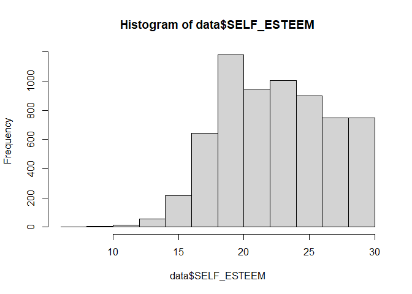

```r
#explore the distribution of the DV
hist(data$SELF_ESTEEM)
```

Run a ANOVA model.

```r
#Perform ANOVA

## make sure SEX and RACE are converted as categorical variables
data$SEX <- as.factor(data$SEX)
data$RACE <- as.factor(data$RACE)

aov.1 <- aov(SELF_ESTEEM ~ SEX+RACE, data = data)
summary(aov.1)
```

```
##               Df Sum Sq Mean Sq F value   Pr(>F)
## SEX            1    235   235.2   14.09 0.000176 ***
## RACE           2   1103   551.7   33.05 5.23e-15 ***
## Residuals   6454 107735    16.7
## ---
## Signif. codes:  0 '***' 0.001 '**' 0.01 '*' 0.05 '.' 0.1 ' ' 1
```

Can you identify significant variables from the result table above? What does a significant relationship mean in this case?

**post-hoc analysis** The ANOVA model above is significant. We can run a post-hoc test to show significant group differences.

```r
library(stats)
TukeyHSD(aov.1)
```

```
##   Tukey multiple comparisons of means
##     95% family-wise confidence level
##
## Fit: aov(formula = SELF_ESTEEM ~ SEX + RACE, data = data)
##
## $SEX
##           diff        lwr        upr     p adj
## 2-1 -0.3817114 -0.5810557 -0.1823671 0.0001758
##
## $RACE
##          diff        lwr       upr     p adj
## 2-1 0.8808983 0.48002426 1.2817724 0.0000008
## 3-1 1.2110483 0.85975744 1.5623392 0.0000000
## 3-2 0.3301500 0.04216795 0.6181321 0.0197502
```

```r
#summary stats by groups
tapply(data$SELF_ESTEEM, data$SEX, summary)
```

```
## $`1`
##    Min. 1st Qu.  Median    Mean 3rd Qu.    Max.
##   11.00   20.00   23.00   23.15   26.00   30.00
##
## $`2`
##    Min. 1st Qu.  Median    Mean 3rd Qu.    Max.
##    7.00   20.00   23.00   22.76   26.00   30.00
```

```r
tapply(data$SELF_ESTEEM, data$RACE, summary)
```

```
## $`1`
##    Min. 1st Qu.  Median    Mean 3rd Qu.    Max.
##   11.00   19.00   21.00   21.99   25.00   30.00
##
## $`2`
##    Min. 1st Qu.  Median    Mean 3rd Qu.    Max.
##    9.00   20.00   23.00   22.87   26.00   30.00
##
## $`3`
##    Min. 1st Qu.  Median    Mean 3rd Qu.    Max.
##     7.0    20.0    23.0    23.2    26.0    30.0
```

## Regression

**How do SEX, RACE, and INCOME predict SELF-ESTEEM?** Answering the question above requires using more than one independent variable and some of the independent variables are categorical and others are continuous.This is where regression comes into play. You use regression when your dependent variable is continuous and your independent variables are continuous or when your independent variables are mixed (i.e., some are continuous and others are categorical).

Perform regression

```r
lm.1 <- lm(SELF_ESTEEM ~ SEX+RACE+INCOME, data = data)
summary(lm.1)
```

```
##
## Call:
## lm(formula = SELF_ESTEEM ~ SEX + RACE + INCOME, data = data)
##
## Residuals:
##      Min       1Q   Median       3Q      Max
## -15.9512  -3.1439  -0.1012   3.2369   8.2586
##
## Coefficients:
##               Estimate Std. Error t value Pr(>|t|)
## (Intercept)  2.208e+01  1.535e-01 143.871  < 2e-16 ***
## SEX2        -3.423e-01  1.032e-01  -3.318  0.00091 ***
## RACE2        9.059e-01  1.715e-01   5.283 1.31e-07 ***
## RACE3        1.210e+00  1.498e-01   8.074 8.03e-16 ***
## INCOME       2.916e-05  1.526e-05   1.910  0.05617 .
## ---
## Signif. codes:  0 '***' 0.001 '**' 0.01 '*' 0.05 '.' 0.1 ' ' 1
##
## Residual standard error: 4.085 on 6453 degrees of freedom
## Multiple R-squared:  0.01283,    Adjusted R-squared:  0.01222
## F-statistic: 20.97 on 4 and 6453 DF,  p-value: < 2.2e-16
```

Take a closer look at the regression model

```r
library(lm.beta)
lm.beta(lm.1)
```

```
##
## Call:
## lm(formula = SELF_ESTEEM ~ SEX + RACE + INCOME, data = data)
##
## Standardized Coefficients::
## (Intercept)        SEX2       RACE2       RACE3      INCOME
##  0.00000000 -0.04164457  0.09363665  0.14269892  0.02412368
```